# Impacto del transporte entre la residencia del alumno y la universidad en su tiempo efectivo de trabajo y rendimiento académico

**3. Tiempo de Transporte semanal y Horas de Sueño diarias**

```r
Trans_Sueño=lm(DF$Tiempo_Dormir~DF$Transporte_Semanal)
summary(Trans_Sueño)
```

```
##
## Call:
## lm(formula = DF$Tiempo_Dormir ~ DF$Transporte_Semanal)
##
## Residuals:
##     Min      1Q  Median      3Q     Max
## -3.5199 -0.5296 -0.0410  0.7887  2.0334
##
## Coefficients:
##                         Estimate Std. Error t value Pr(>|t|)
## (Intercept)            6.6049783  0.1480073  44.626  < 2e-16 ***
## DF$Transporte_Semanal -0.0007094  0.0002325  -3.051  0.00263 **
## ---
## Signif. codes:  0 '***' 0.001 '**' 0.01 '*' 0.05 '.' 0.1 ' ' 1
##
## Residual standard error: 1.128 on 178 degrees of freedom
## Multiple R-squared:  0.04969,    Adjusted R-squared:  0.04435
## F-statistic: 9.307 on 1 and 178 DF,  p-value: 0.002633
```

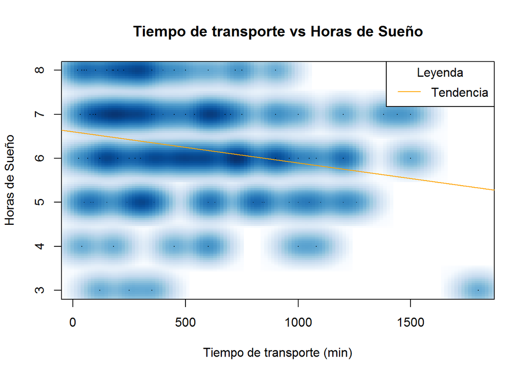

```r
smoothScatter(DF$Transporte_Semanal,DF$Tiempo_Dormir,xlab= "Tiempo de transporte (min)",ylab="Horas de Sueño",main="Tiempo de transporte vs Horas de Sueño")
abline(Trans_Sueño, col='orange')
legend("topright", c("Tendencia"),lty=c(1, 1), col=c("orange"),title="Leyenda",bg="white")
```

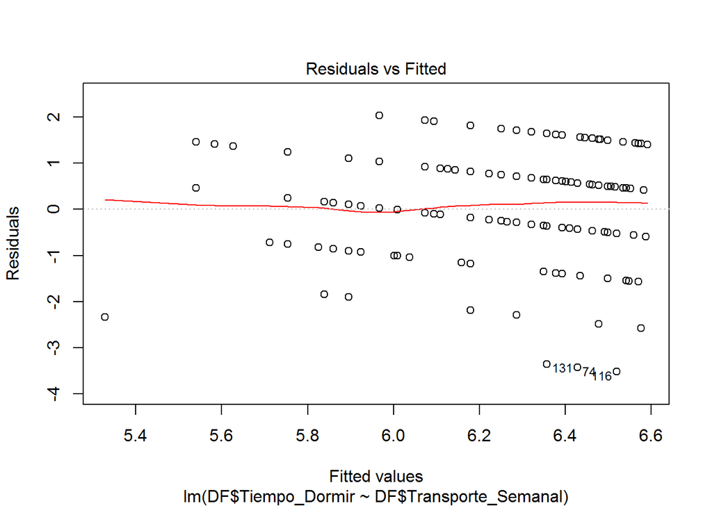

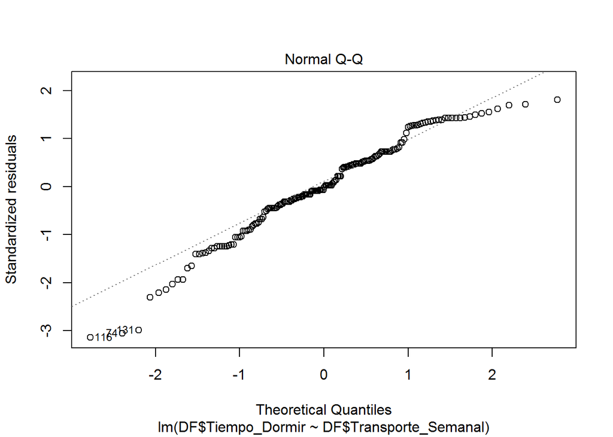

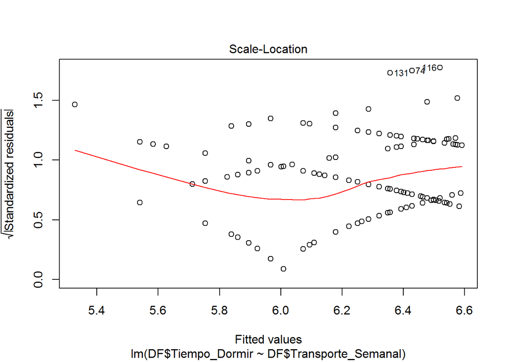

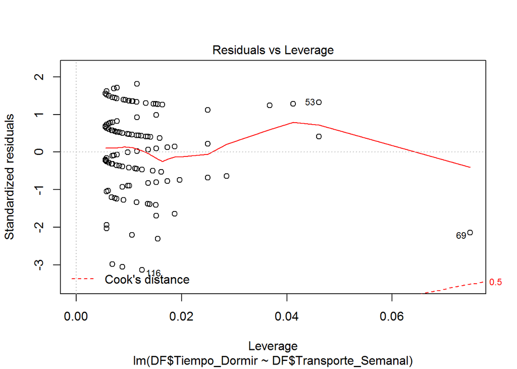

```r
plot(Trans_Sueño)
```

**Análisis** Al analizar el modelo obtenido se observa un p.value igual a 0.002633, por lo que al ser menor a la significancia se rechaza la hipótesis nula, la cual era la no dependencia de la variable horas de sueño con respecto al tiempo de transporte diario. Asimismo, en vista del valor del r cuadrado (0.04969) y la heterocedasticidad de los errores se concluye que el modelo no permite explicar la variación de la variable de manera adecuada, por lo que es insuficiente para realizar predicción sobre esta variable; por lo que se concluye que el modelo no es adecuado para realizar predicción sobre la variable.

**4. Tiempo de Transporte semanal y Calificación del Transporte** Para realizar regresión sobre la variable calificación del transporte se aclara que este modelo funciona tomando la escala con la que se trabajo en el proyecto: 1(malo)-10(bueno), por lo que la variable calificación del transporte solo podría asumir valores enteros en este rango.

```r
Trans_Calif=lm(DF$Calificacion~DF$Transporte_Semanal)
summary(Trans_Calif)
```

```
##
## Call:
## lm(formula = DF$Calificacion ~ DF$Transporte_Semanal)
##
## Residuals:
##     Min      1Q  Median      3Q     Max
## -5.9840 -0.9365  0.1790  1.3831  4.0128
##
## Coefficients:
##                         Estimate Std. Error t value Pr(>|t|)
## (Intercept)            8.3130122  0.2434415  34.148  < 2e-16 ***
## DF$Transporte_Semanal -0.0033226  0.0003825  -8.688 2.35e-15 ***
## ---
## Signif. codes:  0 '***' 0.001 '**' 0.01 '*' 0.05 '.' 0.1 ' ' 1
##
## Residual standard error: 1.855 on 178 degrees of freedom
## Multiple R-squared:  0.2978, Adjusted R-squared:  0.2938
## F-statistic: 75.48 on 1 and 178 DF,  p-value: 2.349e-15
```

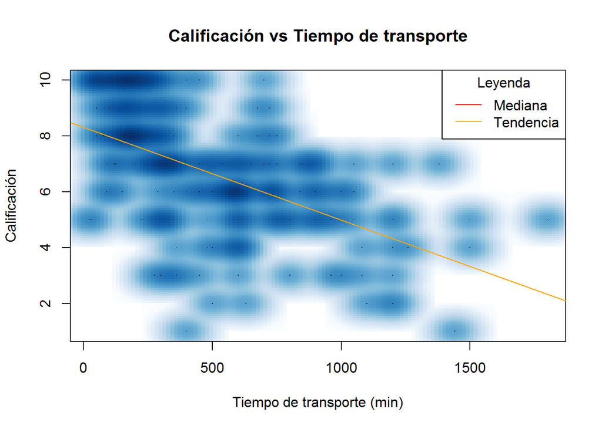

```r
smoothScatter(DF$Transporte_Semanal,DF$Calificacion,xlab= "Tiempo de transporte (min)",ylab="Calificación",main="Calificación vs Tiempo de transporte")
abline(h=median(DF$Transporte_Semanal),col="red")
abline(Trans_Calif, col='orange')
legend("topright", c("Mediana", "Tendencia"),lty=c(1, 1), col=c("red","orange"),title="Leyenda",bg="white")
```

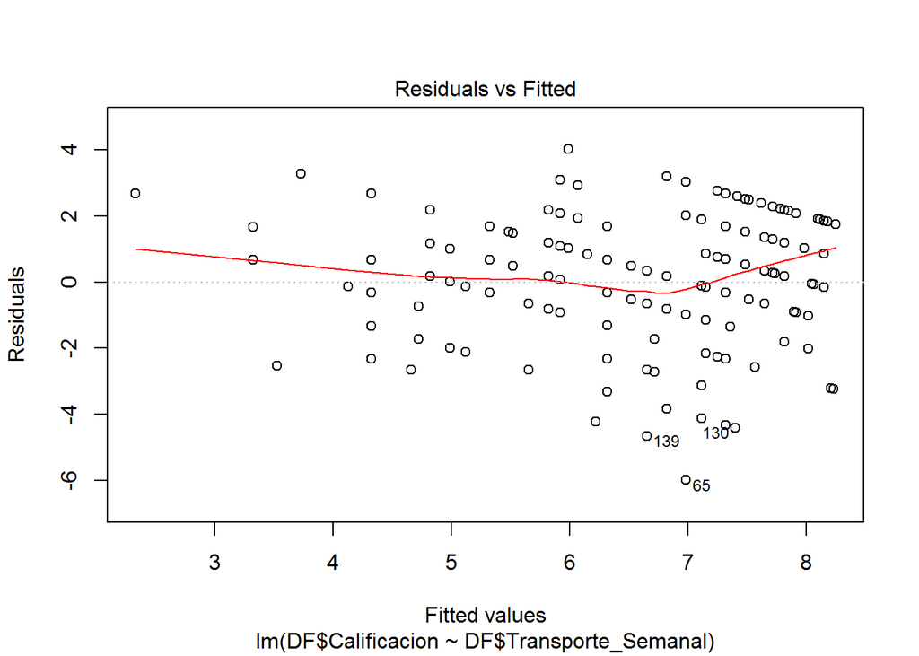

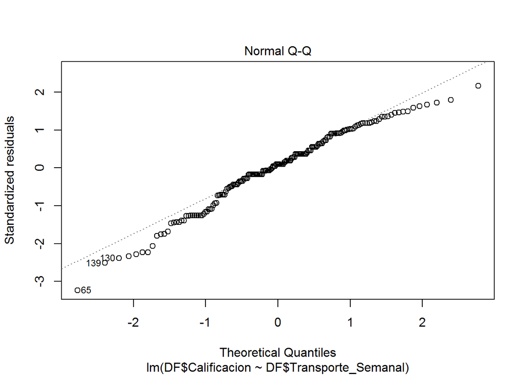

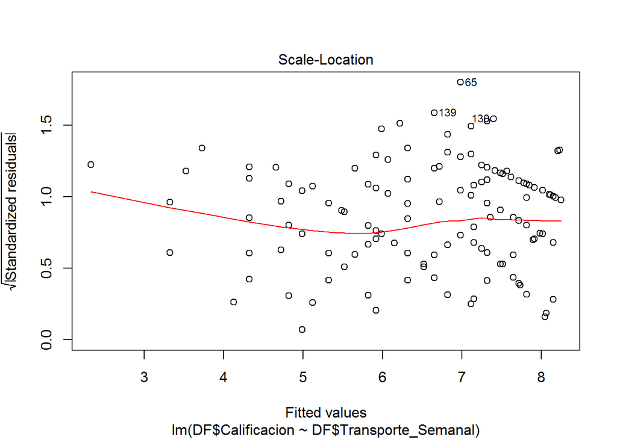

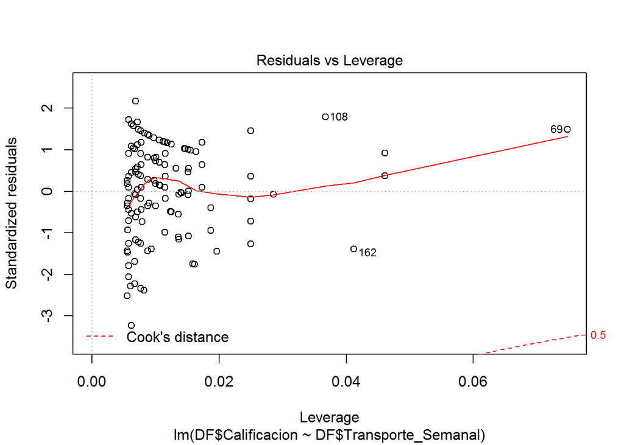

```r
plot(Trans_Calif)
```

**Análisis** Al analizar el modelo obtenido se observa un p.value igual a 2.349e-15, por lo que al ser menor a la significancia se rechaza la hipótesis nula, la cual era la no dependcia de la variable. Asimismo, dado el valor del r cuadrado se puede decir que el modelo explica el 29.78% de la variación de la variable dependiente. A lo que se suma el gráfico del modelo donde se observa una tendencia bastante robusta. A pesar de todo esto, al observar el gráfico de los residuos del modelo se observa heterocedasticidad y en el gráfico de la normal se observan los valores muy dispersos de la tendencia que deberían seguir por lo que se concluye que el modelo no es adecuado para realizar predicción sobre la variable.

**Horas de Sueño en función del Nivel de Estrés y el Tiempo de Transporte Semanal**

```r
R_Sueño=lm(DF$Tiempo_Dormir~DF$Transporte_Semanal+DF$Estres)
summary(R_Sueño)
```

```
##
## Call:
## lm(formula = DF$Tiempo_Dormir ~ DF$Transporte_Semanal + DF$Estres)
##
## Residuals:
##     Min      1Q  Median      3Q     Max
## -3.4397 -0.6727  0.0299  0.8285  2.1921
##
## Coefficients:
##                         Estimate Std. Error t value Pr(>|t|)
## (Intercept)            7.0623819  0.2193894  32.191  < 2e-16 ***
## DF$Transporte_Semanal -0.0005481  0.0002380  -2.302  0.02250 *
## DF$EstresB            -0.6894666  0.2538811  -2.716  0.00728 **
## DF$EstresC            -0.4857079  0.2581361  -1.882  0.06156 .
## DF$EstresD            -0.7387279  0.2963472  -2.493  0.01361 *
## DF$EstresE            -0.9256702  0.3617361  -2.559  0.01135 *
## ---
## Signif. codes:  0 '***' 0.001 '**' 0.01 '*' 0.05 '.' 0.1 ' ' 1
##
## Residual standard error: 1.108 on 174 degrees of freedom
## Multiple R-squared:  0.1036, Adjusted R-squared:  0.07781
## F-statistic: 4.021 on 5 and 174 DF,  p-value: 0.001775
```

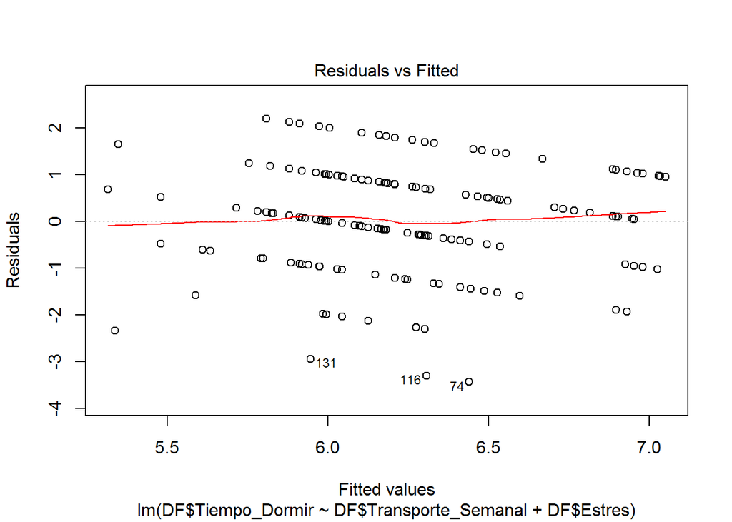

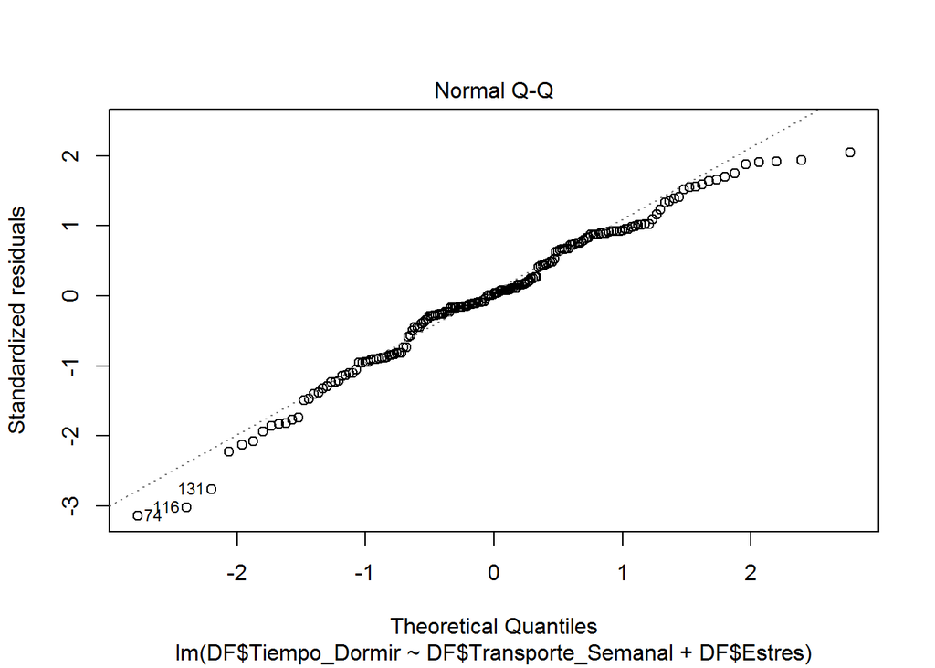

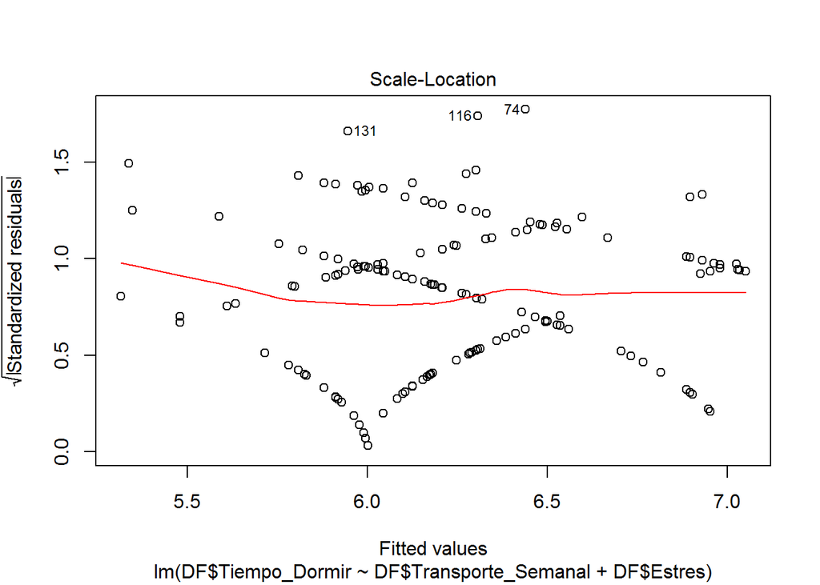

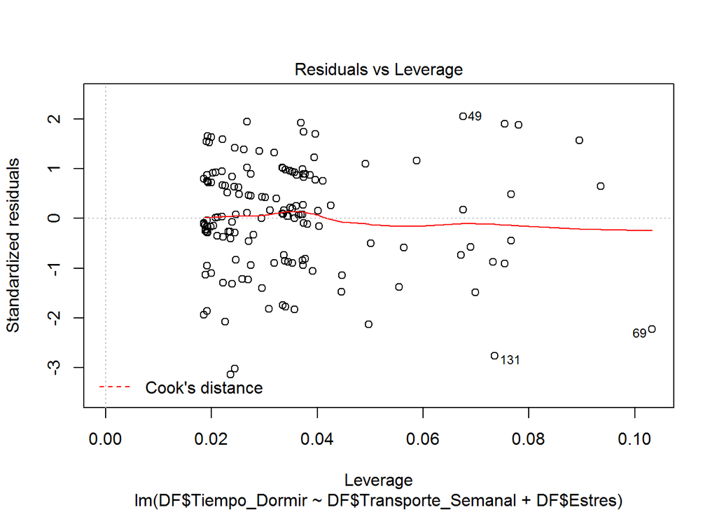

```r
plot(R_Sueño)
```

**Análisis** Al analizar el modelo obtenido se observa un p.value igual a 0.001775, por lo que al ser menor a la significancia se rechaza la hipótesis nula, la cual era la no dependencia de la variable. Asimismo, en vista de la heterocedasticidad de los errores y el valor del r cuadrado(0.1036) se concluye que si bien el modelo explica el 10.36% de la variación de la variable dependiente, este no es adecuado para explicar el comportamiento de esta y por lo tanto tampoco para realizar predicción sobre esta variable.

**Calificación en función del Tiempo de Transporte Semanal y el principal Medio de Transporte** Para realizar regresión sobre la variable calificación del transporte se aclara que este modelo funciona tomando la escala con la que se trabajo en el proyecto: 1(malo)-10(bueno), por lo que la variable calificación del transporte solo podría asumir valores enteros en este rango.

```r
R_Calif1=lm(DF$Calificacion~DF$Transporte_Semanal+DF$M1)
summary(R_Calif1)
```

```
##
## Call:
## lm(formula = DF$Calificacion ~ DF$Transporte_Semanal + DF$M1)
##
## Residuals:
##    Min     1Q Median     3Q    Max
## -6.293 -1.070  0.202  1.169  3.701
##
## Coefficients:
##                                      Estimate Std. Error t value Pr(>|t|)
## (Intercept)                         9.5057764  0.5132635  18.520  < 2e-16 ***
## DF$Transporte_Semanal              -0.0024889  0.0004365  -5.701 5.11e-08 ***
## DF$M1Carro Particular              -1.2166960  0.5790292  -2.101  0.03708 *
## DF$M1Combi / micro                 -2.5266152  0.6035355  -4.186 4.53e-05 ***
## DF$M1Metropolitano / Corredor rojo -2.0044517  0.6688324  -2.997  0.00313 **
## DF$M1Otro                           0.5440012  1.8388302   0.296  0.76771
## DF$M1Taxi                          -1.1674206  0.6390912  -1.827  0.06949 .
## DF$M1Tren electrico                -1.6131165  1.0449319  -1.544  0.12450
## DF$M1Voy caminando                 -1.2410374  0.8831574  -1.405  0.16177
## ---
## Signif. codes:  0 '***' 0.001 '**' 0.01 '*' 0.05 '.' 0.1 ' ' 1
##
## Residual standard error: 1.766 on 171 degrees of freedom
## Multiple R-squared:  0.3884, Adjusted R-squared:  0.3598
## F-statistic: 13.58 on 8 and 171 DF,  p-value: 3.804e-15
```

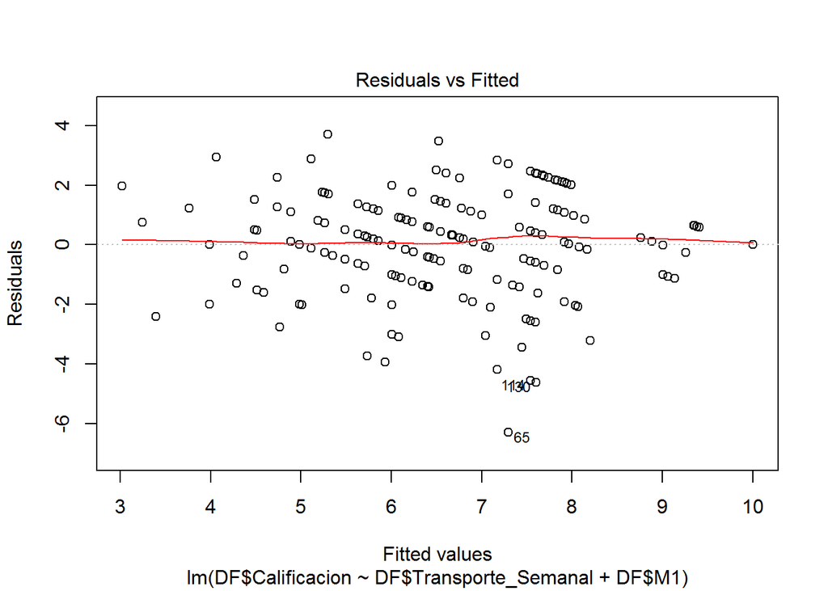

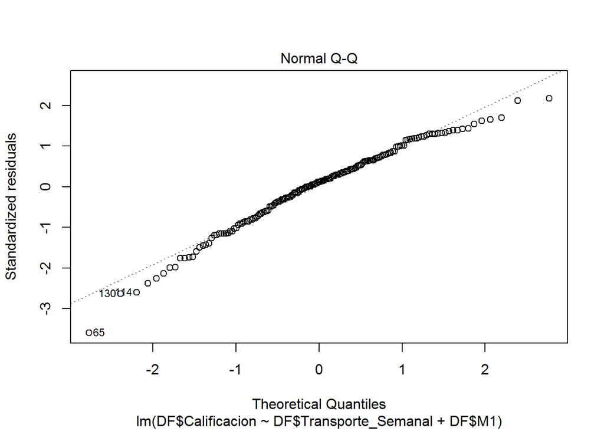

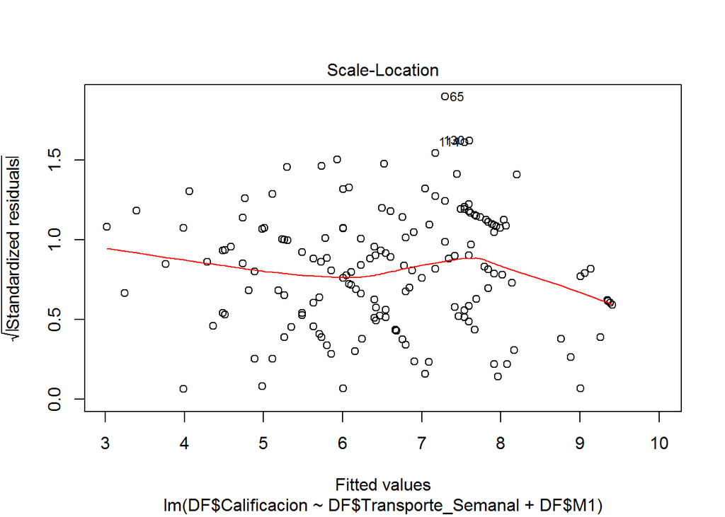

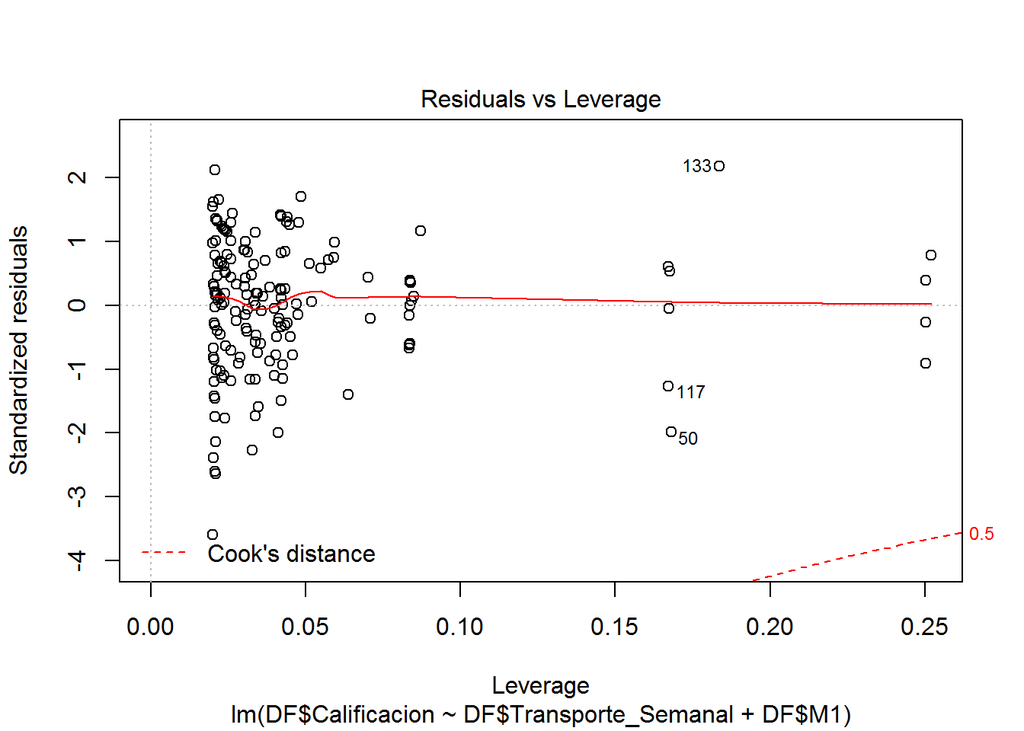

```r
plot(R_Calif1)
```

**Análisis** Al analizar el modelo obtenido se observa un p.value igual a 3.804e-15, por lo que al ser menor a la significancia se rechaza la hipótesis nula, la cual era la no dependencia de la variable. Asimismo, dado el valor del r cuadrado se puede decir que el modelo explica el 38.84% de la variación de la variable dependiente. Finalmente, en el gráfico de residuos del modelo se puede observar heterocedasticidad en los residuos por lo que se concluye que el modelo no es adecuado para realizar predicción sobre la variable.

**Calificación en función del Tiempo de Transporte Semanal y el principal Medio de Transporte dividido en 3 categorías** Asimismo decidimos intentar un nuevo modelo organizando a la variable de principal medio de transporte en 3 categorías:

```r
DF$M1[DF$M1=="Carro Particular"]="Z Particular"
DF$M1[DF$M1=="Combi / micro"]="Z Público"
DF$M1[DF$M1=="Metropolitano / Corredor rojo"]="Z Público"
DF$M1[DF$M1=="Taxi"]="Z Particular"
DF$M1[DF$M1=="Tren electrico"]="Z Público"
DF$M1[DF$M1=="Bicicleta / scooter"]="Z Caminando/Bicicleta/Similar"
DF$M1[DF$M1=="Voy caminando"]="Z Caminando/Bicicleta/Similar"
```

```r
R_Calif2=lm(DF$Calificacion~DF$Transporte_Semanal+DF$M1)
summary(R_Calif2)
```

```
##
## Call:
## lm(formula = DF$Calificacion ~ DF$Transporte_Semanal + DF$M1)
##
## Residuals:
##     Min      1Q  Median      3Q     Max
## -6.3064 -0.8495  0.1630  1.2228  3.4601
##
## Coefficients:
##                                     Estimate Std. Error t value Pr(>|t|)
## (Intercept)                        10.047242   1.767180   5.685 5.37e-08 ***
## DF$Transporte_Semanal              -0.002362   0.000421  -5.610 7.77e-08 ***
## DF$M1Z Caminando/Bicicleta/Similar -0.973985   1.816392  -0.536    0.592
## DF$M1Z Particular                  -1.796010   1.787181  -1.005    0.316
## DF$M1Z Público                     -2.912941   1.799775  -1.619    0.107
## ---
## Signif. codes:  0 '***' 0.001 '**' 0.01 '*' 0.05 '.' 0.1 ' ' 1
##
## Residual standard error: 1.767 on 175 degrees of freedom
## Multiple R-squared:  0.3733, Adjusted R-squared:  0.359
## F-statistic: 26.06 on 4 and 175 DF,  p-value: < 2.2e-16
```

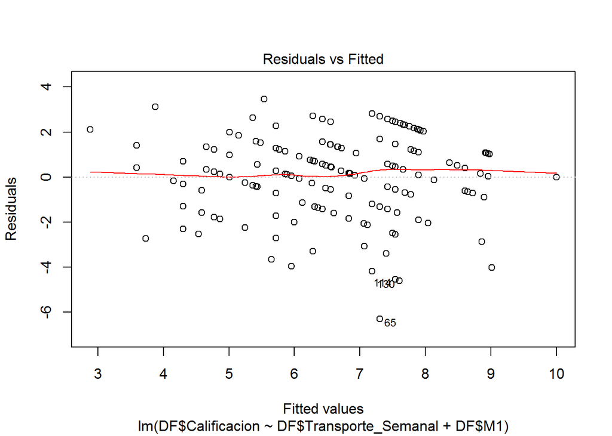

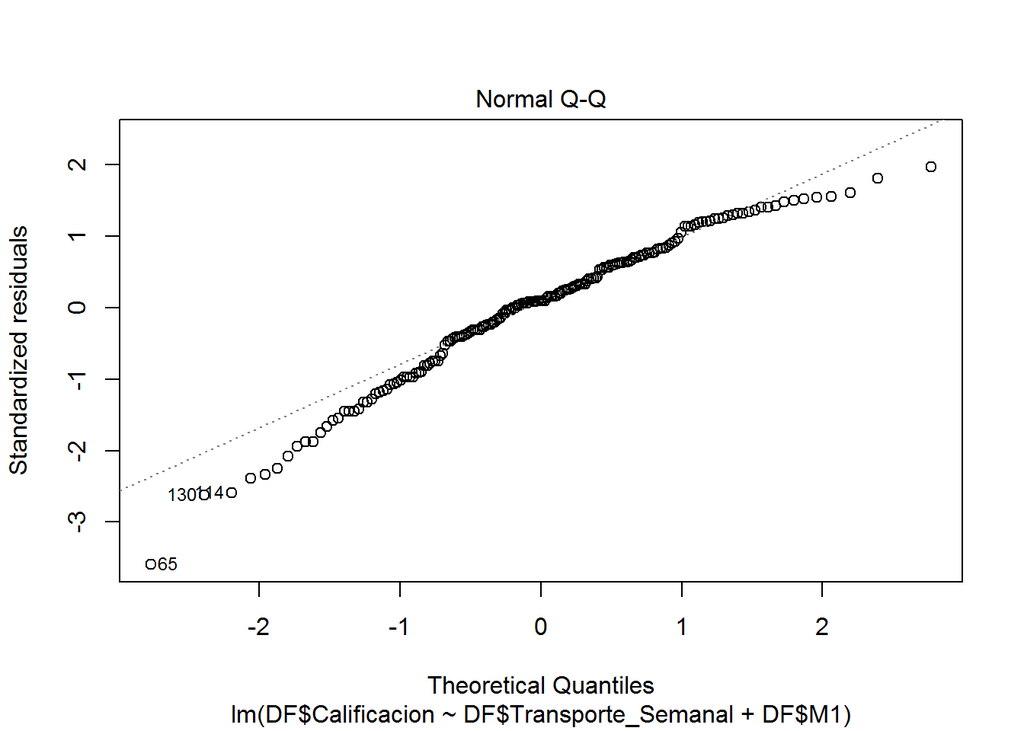

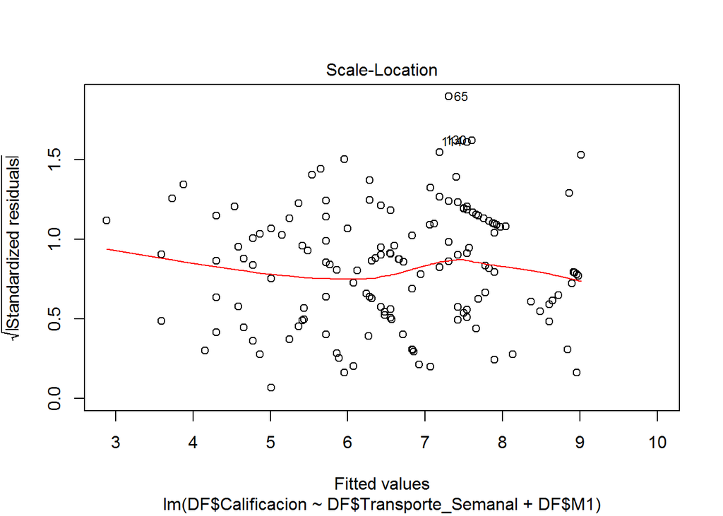

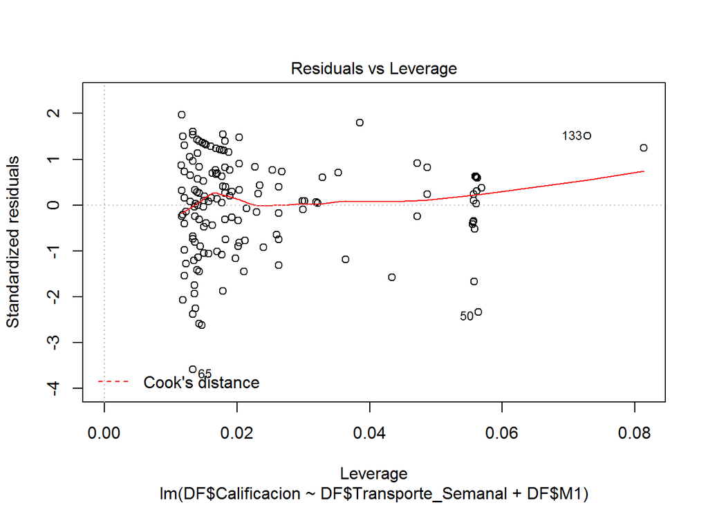

```r
plot(R_Calif2)
```

**Análisis** Al analizar este modelo se observa un p.value igual a 2.2e-16, por lo que al ser menor a la significancia se rechaza la hipótesis nula, la cual era la no dependencia de la variable. Asimismo, al obtenerse todos los p.values de la variable medio de transporte mayores a la significancia. No se puede rechazar la hipótesis nula, la cual establece la no dependencia de la calificación con respecto a la principal medio de transporte. Además, dado el valor del r cuadrado se puede decir que el modelo explica el 37.33% de la variación de la variable dependiente, lo cual sería inferior a cuando se toma la variable principal medio de transporte sin agrupar. Finalmente, en el gráfico de residuos del modelo se puede observar heterocedasticidad en los residuos por lo que se concluye que el modelo no es adecuado para realizar predicción sobre la variable.

### CONCLUSIONES:

De los análisis realizados en la parte inferencial se puede concluir que:

**#** Se encontró dependencia de algunas variables con respecto a otras, siendo las más significativas:

-El tiempo de transporte semanal explica el 29.78% de la variación de la calificación del transporte.

-El modelo con las variables independientes nivel de estrés y tiempo de transporte semanal explica el 10.36% de la variación de las horas de sueño diarias.

-El modelo con las variables independientes medio de transporte semanal y tiempo de transporte semanal explica el 38.84% de la variación de la calificación de la experiencia del transporte.

**#** No se pudo rechazar al 5% de significancia la no dependencia del número de cursos reprobados con respecto al tiempo de transporte diario.

**#** Respecto a los modelos obtenidos por regresión, no se encontró ninguno que sea lo suficientemente robusto como para realizar predicción sobre alguna variable debido principalmente a la heterocedasticidad en los residuos de estos.

### Bibliografía:

- https://gestion.pe/tendencias/lima-ciudades-peor-trafico-269483-noticia/
- https://amp.milenio.com/especiales/estres-cronico-como-identificarlo